# Probing Spatio-temporal Receptive Fields In Surrogate Cortical Circuits

## Software stack - Stimulus modes

[figure not shown]

### Localized Flashing

Specific area of screen flashed with a on-off duty cycle

[figure not shown]

### Poisson-Bernoulli

Random uncorrelated spatiotemporal block checkerboards

[figure not shown]

### Orientational gratings

Sinusoidal gratings with variable grating and temporal parameters

## Software stack - Stimulus modes - Poisson-Bernoulli Stimulus

[figure not shown]

### Poisson-Bernoulli

Random uncorrelated spatiotemporal block checkerboards. With p_on values for sparsity and different resolutions.

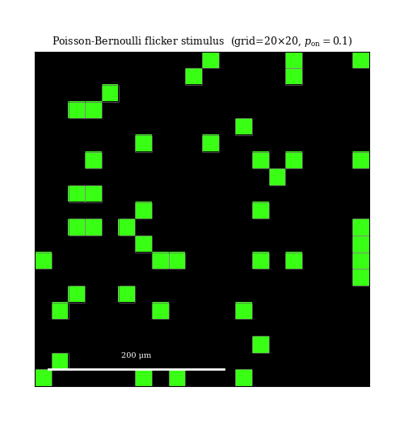

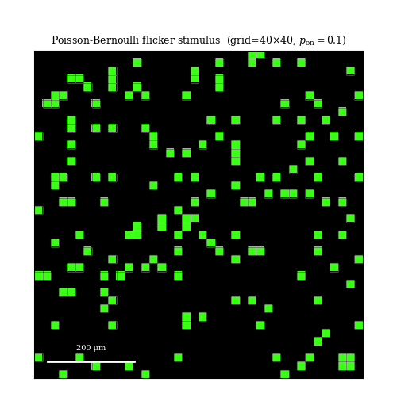

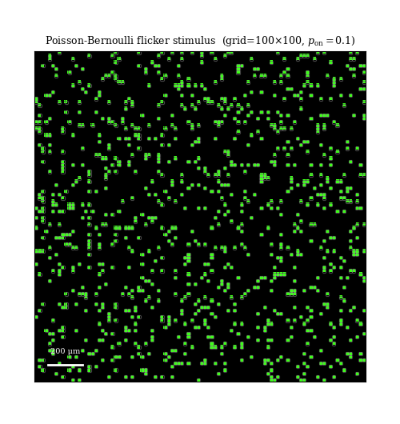

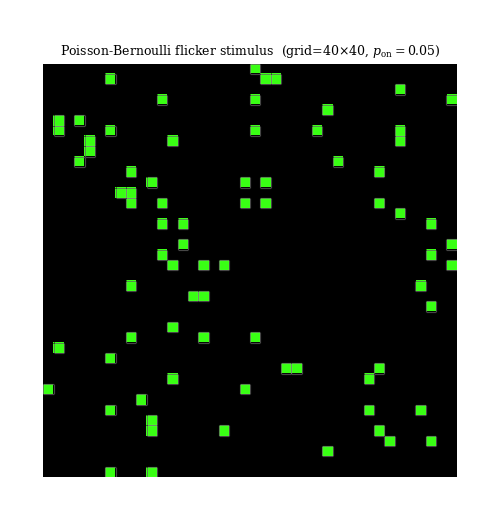

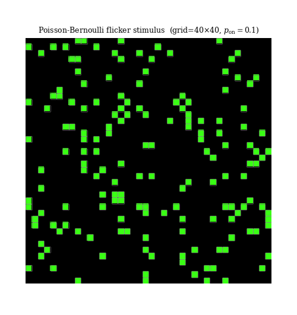

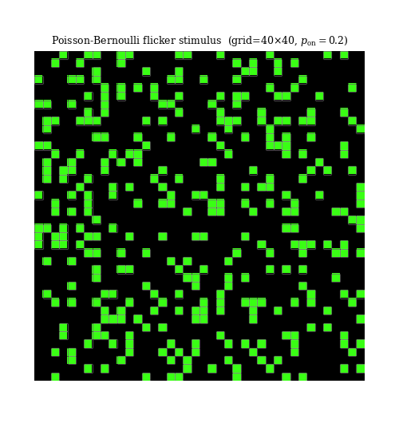

## Software stack - Stimulus modes - Orientational gratings

[figure not shown]

### Orientational Gratings

Sinusoidal gratings with controllable direction, wavelength and frequency.

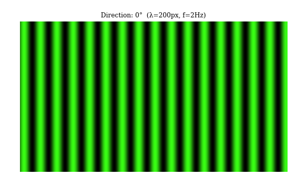

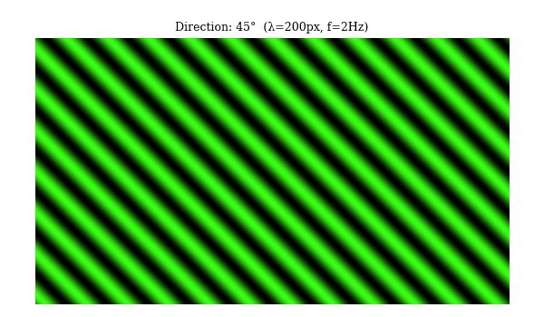

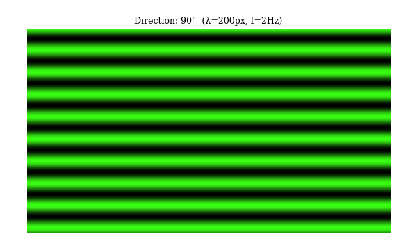

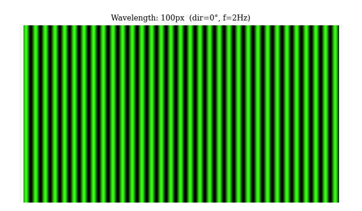

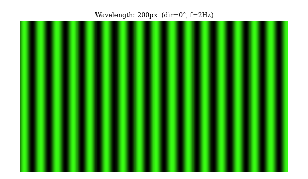

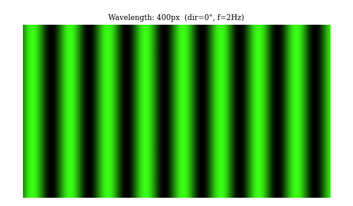

$$\boxed{f(x, y, t) = \sin\!\left(\frac{2\pi}{\lambda}
\left(x\cos\theta + y\sin\theta\right) + \omega t\right)}$$

## Frame times as a sync signal

Frame times are logged directly from the GPU

### Setup

[figure not shown]

### Oscilloscope traces

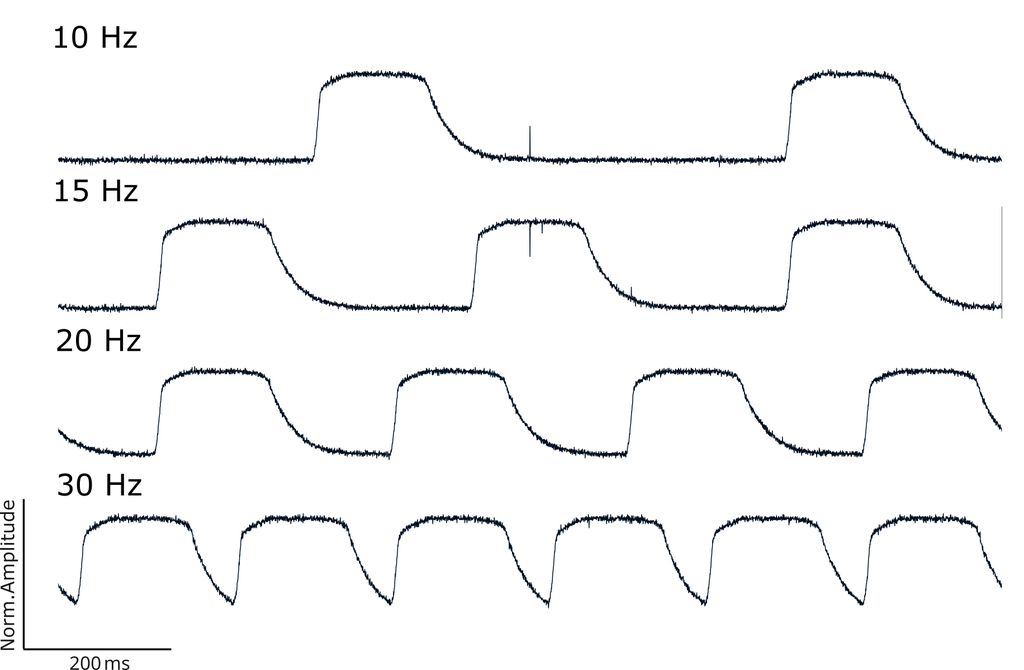

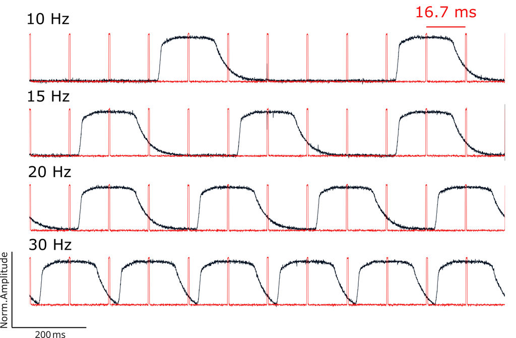

## Results

## Results - Recording fidelity of the Maxwell System

### Spontaneous activity DIV 20

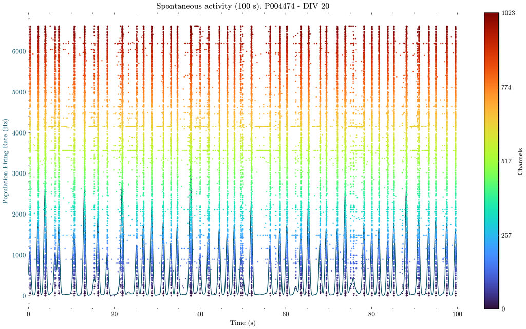

### Analysis

- Only units with > 1000 spikes are selected for analysis
- The stimulus ensemble is mean centered first
- All STAs are z-scored as

$$\hat{k}(\mathbf{x}, \tau_k) = \frac{k(\mathbf{x}, \tau_k) - \mu_k}{\sigma_k}$$

## Increasing stimulus resolution increase STA features

[figure not shown]

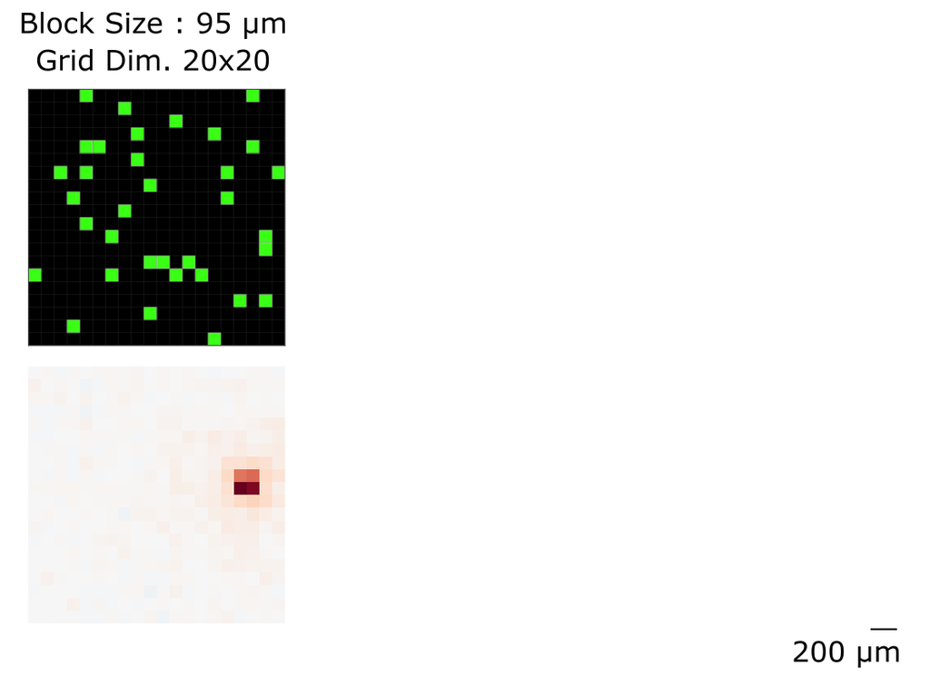

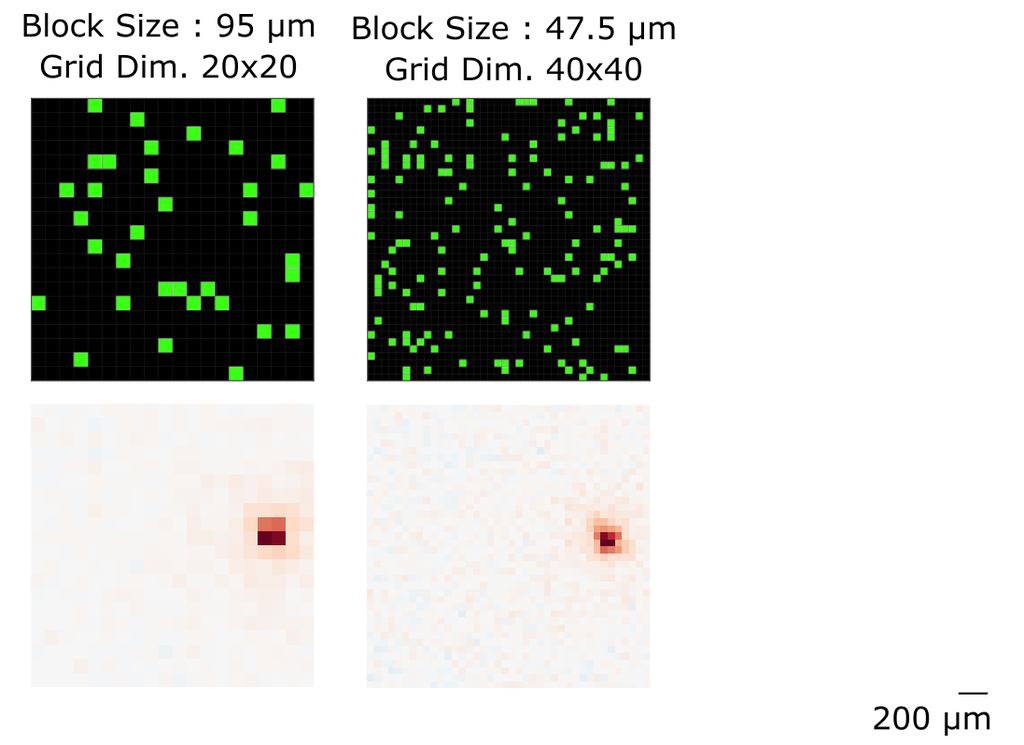

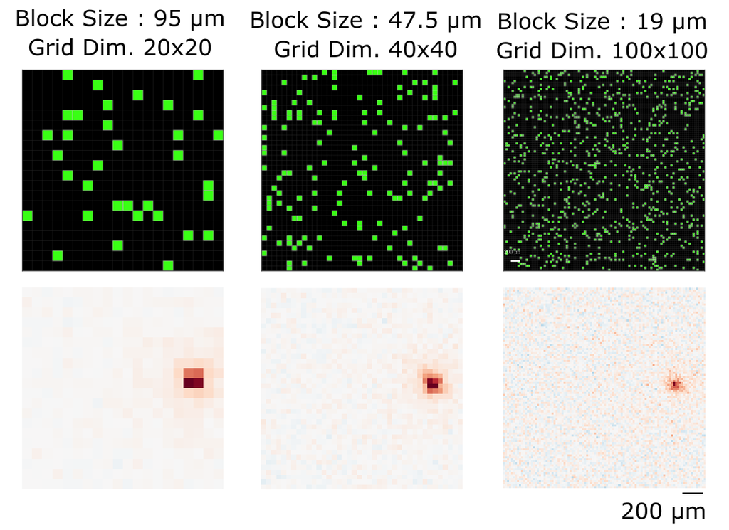

- Experiment duration : 15 min
- Approx spikes collected : ~ 2000

## High resolution low noise STAs reveal complex structures

[figure not shown]

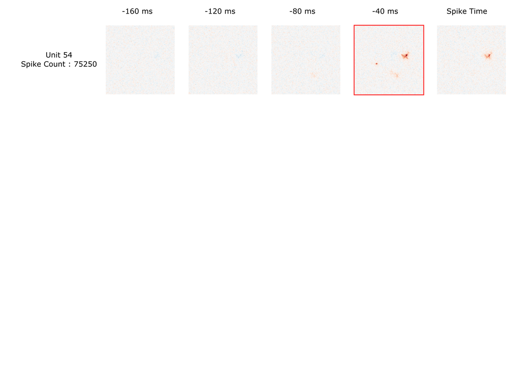

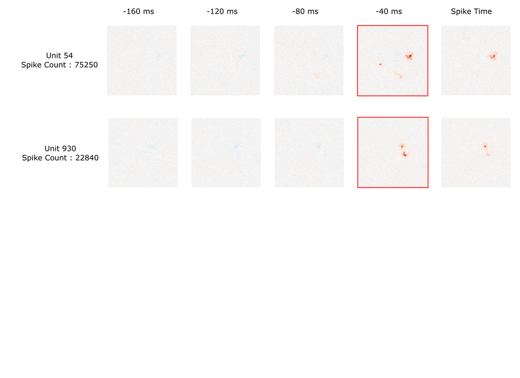

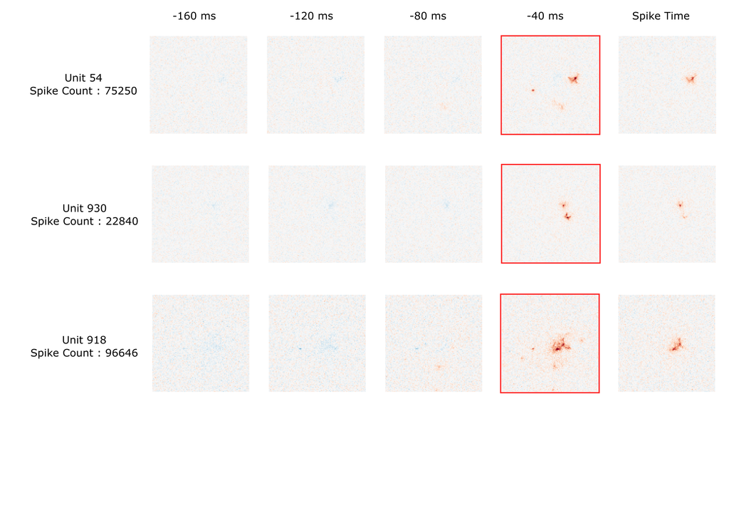

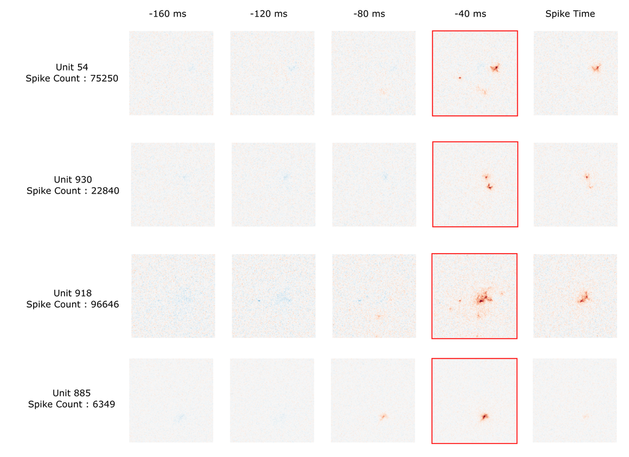

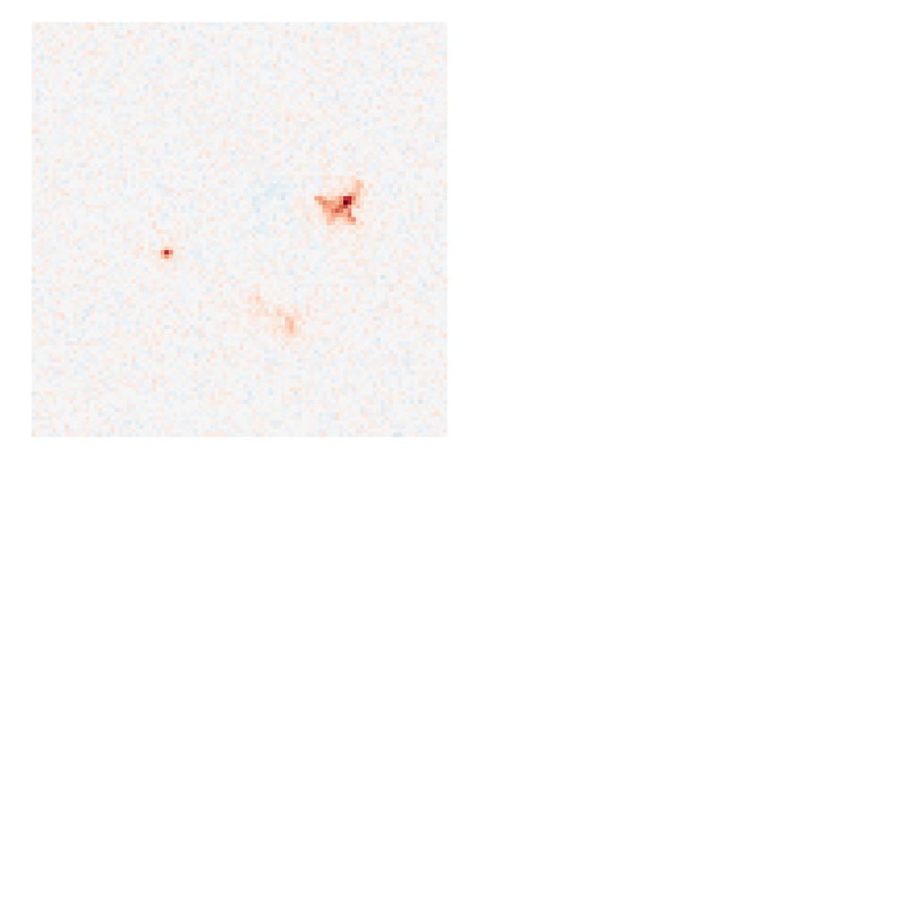

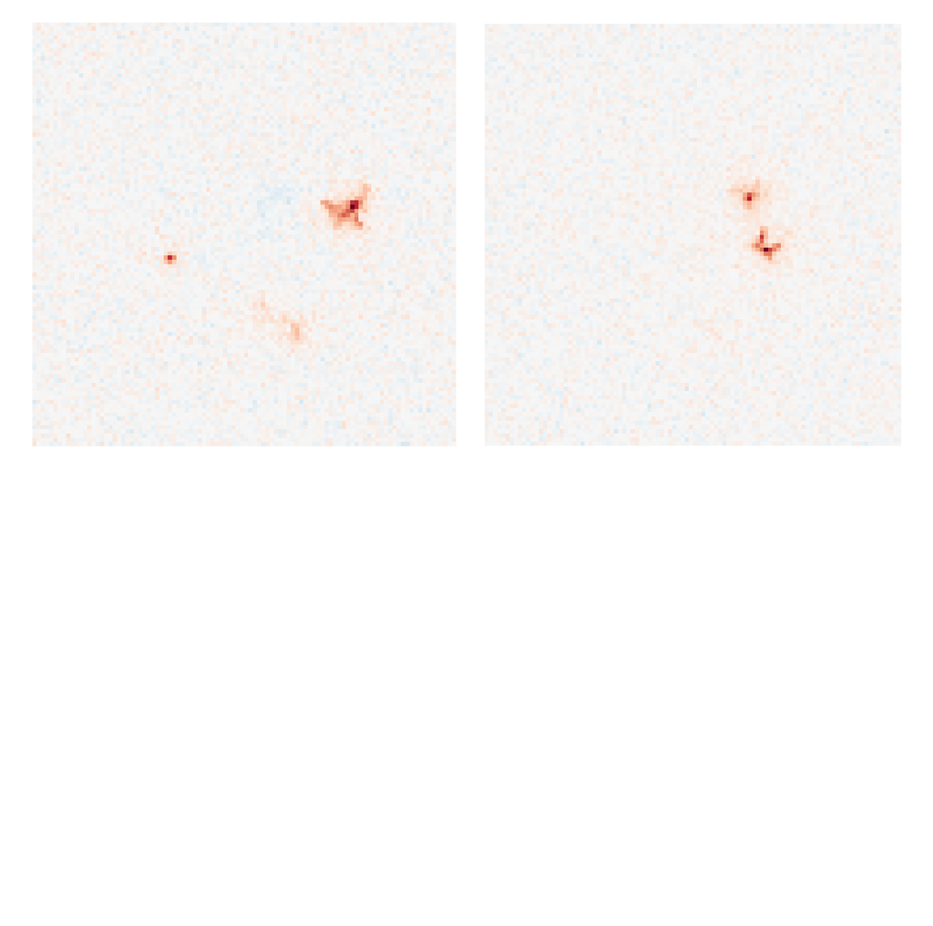

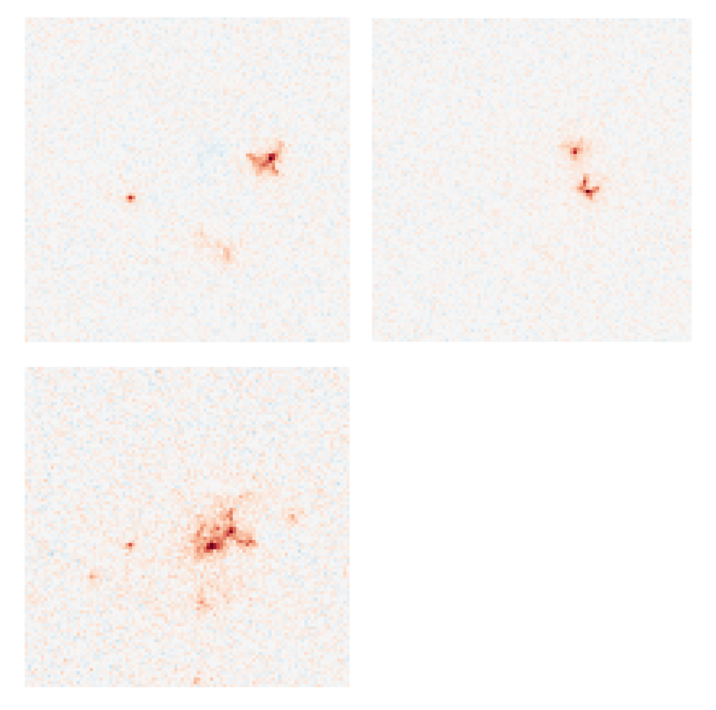

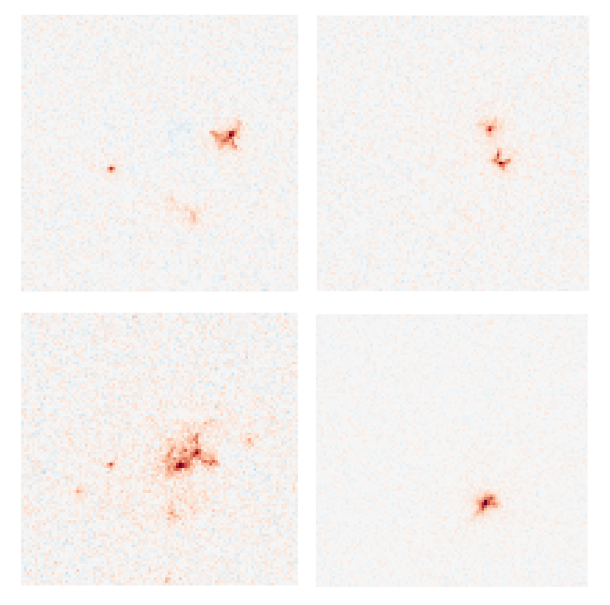

[figure not shown]

Campus Institute for Dynamics of Biological Networks (CIDBN), University of Gottingen